# SMP population assesment

Farshad Ebrahimi, Jan/11/2023

**Motivation**

The goal of this analysis is to assess the SMP population with CWL monitoring data, categorize them and find the underrepresented smp features in our data set. This is to ensure our monitoring effort results in a more comprehensive data set that covers all types of SMPs with varying design metrics such as loading ratios. The output of this analysis can assist the data collection team with their future site selection process.

```r
#Libraries
      library(odbc)
      library(DBI)
      library(lubridate)
      library(tidyverse)
      library(stats)
      library(gridExtra)
      library(grid)
      library(gtable)
      library(ggtext)
      library(dplyr)
      library(ggplot2)
      library(knitr)
# DB PG14
    con <- dbConnect(odbc::odbc(), dsn = "mars14_data", uid = Sys.getenv("shiny_uid"), pwd = Sys.getenv("shiny_pwd"), MaxLongVarcharSize = 8190)

#Getting list of SMPs
    cwl_smp <- dbGetQuery(con,"SELECT DISTINCT smp_id
           FROM fieldwork.viw_deployment_full_cwl")

#Getting the greenit info
    smpbdv <- dbGetQuery(con,"SELECT * FROM external.tbl_smpbdv")
    sysbdv <- dbGetQuery(con,"SELECT * FROM external.tbl_systembdv")
    greenit_unified <-dbGetQuery(con,"SELECT * FROM external.viw_greenit_unified")

# join the greenit table with our smp list
    smp_features <- cwl_smp %>%
      inner_join(smpbdv, by="smp_id")
# Unmonitored SMPs
    unmonitored_smp <- read.csv("C:\\Users\\Farshad.Ebrahimi\\OneDrive - City of Philadelphia\\Github Projects\\smp-population-assesment\\unmonitored_sites.csv") %>%
      select(smp_id = SMP.ID) %>%
      distinct()
# unmonitored smp_features
    unmonitored_smp_features <- unmonitored_smp %>%
      inner_join(smpbdv, by="smp_id")
```

The following code chunk calculates the break-down of SMP types with CWL data.

```r
#number of smp types
smp_type_break <- smp_features %>%
  group_by(smp_smptype) %>%
  summarise(count = n()) %>%
  select(Type = smp_smptype, count)
```

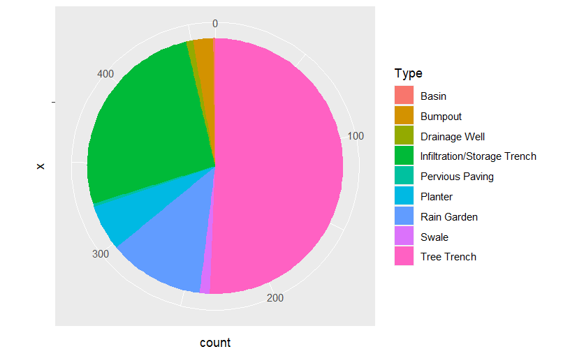

```r
#number of unmonitored smps
unmonitored_smp_type_break <- unmonitored_smp_features %>%
  group_by(smp_smptype) %>%
  summarise(count = n()) %>%
  select(Type = smp_smptype, count)
```

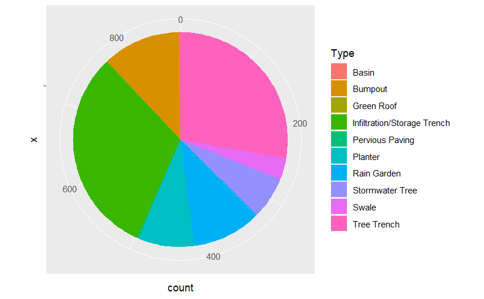

```r
#combining all smps (monitored and unmonitored) and get fractions based on type of smp-finally normalize them
total_smp <- unmonitored_smp_type_break %>%
  full_join(smp_type_break, by="Type")
total_smp[is.na(total_smp)] <- 0
total_smp <- total_smp %>%
  mutate(total_number = count.x+count.y) %>%
  select(Type, total_number)
total_smp <- total_smp %>%
    mutate(sum_all = sum(total_number)) %>%
    mutate(percent_all = (total_number/sum_all)*100)

#get the percent of monitored SMP
smp_type_break_fraction <- smp_type_break %>%
    mutate(sum_all = sum(count)) %>%
    mutate(percent_monitored = (count/sum_all)*100)

#normalize the monitored smp by the total smp percents
normalized_fractions <- smp_type_break_fraction %>%
  full_join(total_smp, by="Type") %>%
  mutate(normalized_percent = percent_monitored/percent_all) %>%
  select(Type, percent_monitored, percent_all, normalized_percent)

normalized_fractions[is.na(normalized_fractions)] <- 0
```

The following table is aimed to identify the over-representing (normalized percent > 1) and under-representing (normalized percent <1) SMP types.

```r
#calculating the normalized percentage of smp types
kable(arrange(normalized_fractions, normalized_percent), caption = "Normalized SMP Break-down")
```

Normalized SMP Break-down

| Type | percent_monitored | percent_all | normalized_percent |
| --- | --- | --- | --- |
| Green Roof | 0.0000000 | 0.1490313 | 0.0000000 |
| Stormwater Tree | 0.0000000 | 4.1728763 | 0.0000000 |
| Bumpout | 2.5862069 | 8.4947839 | 0.3044465 |
| Swale | 1.2931034 | 2.5335320 | 0.5103955 |
| Planter | 5.8189655 | 7.5260805 | 0.7731734 |
| Infiltration/Storage Trench | 26.0775862 | 29.5081967 | 0.8837404 |
| Basin | 0.2155172 | 0.2235469 | 0.9640805 |
| Rain Garden | 12.0689655 | 11.1028316 | 1.0870169 |
| Tree Trench | 50.6465517 | 35.6929955 | 1.4189493 |
| Pervious Paving | 0.4310345 | 0.2980626 | 1.4461207 |
| Drainage Well | 0.8620690 | 0.2980626 | 2.8922414 |

```r
NA
```

The table above shows Tree trenches are over-represented in our CWL data, while green roof, stormwater tree, bumpout, swale and planters are under-represented (due to monitoring limitation, etc).

The following section is focused on establishing the design metrics range for SMPs in the unmonitored SMP list. These design metrics include drainage area, storm size managed and loading ratio.

```r
#filtering SMPs to the two most common ones: tree trench, and  infiltration/storage trench SMPs
loading_ratio <- greenit_unified %>%
  mutate(loading_ratio = dcia_ft2/storage_footprint_ft2) %>%
  select(smp_id, loading_ratio)

#add the loading ratio to unmonitored_smp_features
unmonitored_smp_all <- unmonitored_smp_features %>%
  left_join(loading_ratio, by="smp_id")

#calcluate stats for  smp footprint, storage depth, and vegetated area, sys-rawstormsizemanaged-in , sys_impervda_ft2, and loading ratio
table_all <- unmonitored_smp_all %>%
  left_join(sysbdv, by="system_id")
```

```r
#Draiange at system level
drainage_area <- table_all %>%
  select(smp_smptype, sys_impervda_ft2) %>%
  distinct() %>%
  na.omit() %>%
  group_by(smp_smptype) %>%
  summarise(number= n(), average_drainage= mean(sys_impervda_ft2), median= median(sys_impervda_ft2), min= min(sys_impervda_ft2), max= max(sys_impervda_ft2))
kable(drainage_area)

#Storm-size managed at system level
storm_managed <- table_all %>%
  select(smp_smptype, sys_rawstormsizemanaged_in) %>%
  distinct() %>%
  na.omit() %>%
  group_by(smp_smptype) %>%
  summarise(number= n(), average_storm= mean(sys_rawstormsizemanaged_in), median= median(sys_rawstormsizemanaged_in), min= min(sys_rawstormsizemanaged_in), max= max(sys_rawstormsizemanaged_in))
kable(storm_managed)

#loading ratio
lr_capacity <- table_all %>%
  select(smp_smptype, loading_ratio) %>%
  distinct() %>%
  na.omit() %>%
  group_by(smp_smptype) %>%
  summarise(number= n(), average_lr= mean(loading_ratio), median= median(loading_ratio), min= min(loading_ratio), max= max(loading_ratio))
kable(lr_capacity)
```

```r
kable(drainage_area, caption = "Draiange Area (ft2) Range-Unmoniotred SMPs")
```

Draiange Area (ft2) Range-Unmoniotred SMPs

| smp_smptype | number | average_drainage | median | min | max |
| --- | --- | --- | --- | --- | --- |
| Basin | 2 | 51368.50 | 51368.5 | 43570 | 59167 |
| Bumpout | 94 | 22044.15 | 19012.0 | 4132 | 58566 |
| Infiltration/Storage Trench | 264 | 23626.83 | 15984.0 | 3168 | 334606 |
| Pervious Paving | 1 | 97993.00 | 97993.0 | 97993 | 97993 |
| Planter | 24 | 22744.75 | 12234.5 | 516 | 140104 |
| Rain Garden | 83 | 28827.94 | 21582.0 | 535 | 100084 |
| Stormwater Tree | 10 | 718.70 | 665.0 | 451 | 1363 |
| Swale | 24 | 22762.83 | 19399.5 | 3267 | 56031 |
| Tree Trench | 235 | 16863.12 | 13393.0 | 720 | 88619 |

```r
kable(lr_capacity, caption = "Loading Ratio Range-Unmoniotred SMPs")
```

Loading Ratio Range-Unmoniotred SMPs

| smp_smptype | number | average_lr | median | min | max |
| --- | --- | --- | --- | --- | --- |
| Infiltration/Storage Trench | 3 | 17.09297 | 12.10375 | 6.070668 | 33.10451 |
| Tree Trench | 8 | 13.55339 | 13.34575 | 8.007605 | 19.18732 |

```r
kable(storm_managed, caption = "Storm Size Managed (in) Range-Unmoniotred SMPs")
```

Storm Size Managed (in) Range-Unmoniotred SMPs

| smp_smptype | number | average_storm | median | min | max |
| --- | --- | --- | --- | --- | --- |
| Basin | 2 | 1.6831279 | 1.6831279 | 1.6646316 | 1.701624 |
| Bumpout | 94 | 1.6965894 | 1.6624091 | 1.0571030 | 2.709528 |
| Green Roof | 2 | 1.7004000 | 1.7004000 | 1.0008000 | 2.400000 |
| Infiltration/Storage Trench | 265 | 1.6810708 | 1.6673312 | 0.1743604 | 5.045454 |
| Pervious Paving | 1 | 4.4558693 | 4.4558693 | 4.4558693 | 4.455869 |
| Planter | 25 | 1.7909240 | 1.4609174 | 0.9788005 | 5.045454 |
| Rain Garden | 83 | 1.8783607 | 1.7485254 | 0.3098551 | 5.979903 |
| Stormwater Tree | 11 | 0.6504578 | 0.7121662 | 0.0000000 | 1.000444 |
| Swale | 24 | 1.8630884 | 1.7679185 | 0.3098551 | 3.162534 |
| Tree Trench | 235 | 1.6389453 | 1.6504502 | 0.3505542 | 2.887762 |